# Inside the Max Planck Institute for Demographic Research

### DATASCI 530 – Project 2 · Xueqian Cheng

This report uses data collected from the institute's website to describe what MPIDR studies, who does the work, and how its publishing has changed since 2005.

**Key findings**

1. **Research is concentrated in a few places.** The two units of the Digital & Computational lab run 58 of the 131 projects (44%). Aging and mortality is the most common topic (a third of projects), and the United States is studied more than Germany, where the institute is based.
2. **Half of all projects involve outside researchers.** This rises to 85% in the Joint research labs, but is below 30% in the Social Demography lab.
3. **Open access became the norm almost overnight.** Fewer than 1 in 4 journal articles were free to read up to 2016; from 2017 on it is 70–94%.
4. **Papers are written by larger teams.** Articles with four or more authors rose from 42% of the total in 2005–09 to 57% in 2020–25, while single-author papers are rare (about 1 in 15).

## 1. Introduction

The **Max Planck Institute for Demographic Research (MPIDR)** in Rostock, Germany, is one of the world's largest research centers for the study of populations: how long people live, when they have children, where they move, and how families and health change over time. Its research is organized into two labs (Social Demography, and Digital & Computational Demography), joint labs run with partner institutions, and independent research groups led by early-career scientists. Together these make up 14 research units.

This report answers three questions:

- **A. How is the research organized?** Which units run the most projects, and which topics and regions do they study?
- **B. Who does the research?** How many projects each researcher works on, and how often projects include people from outside the institute.
- **C. What does MPIDR publish, and how has it changed?** The types of publications, how output has grown, how much of it is free to read, and whether papers are written by larger teams over time.

## 2. Data collection

All data come from the public research pages of the MPIDR website (https://www.demogr.mpg.de/en/research_6120/) and were collected on **24 October 2026** with an automated web browser (Python and Selenium). The code is in the Project 1 notebook. The collection had three steps:

1. **Find the research units.** The *Research* menu lists 17 units. 14 of them have a *Projects* page.
2. **Visit every project.** For each project the program opened its page and recorded the title, the MPIDR team, any outside collaborators and their institutions, the research keywords and regions, and the publications linked to the project.
3. **Collect every unit's publication list.** Project pages only show papers tied to a project, so the program also clicked each unit's *Publications* tab. That list is about 1.6 times longer. For each paper it recorded the title, authors, type, year and whether it is open access.

The result is three tables, described in Table 1 (Section 3). The analysis in this report is reproducible: re-running the Project 1 notebook updates the files, and this notebook recalculates every number and chart from them.

## 3. Data preparation

The three files from Project 1 are loaded and cleaned so they can be summarized: lab names are made readable, research topics and regions are split into separate tags, and duplicate publications are removed. The code is hidden in this report; the short printed lines confirm the size of each dataset.

```python
import re
import pandas as pd
import matplotlib.pyplot as plt
import matplotlib.ticker as mtick
from IPython.display import display

pd.set_option("display.max_colwidth", 80)

# Chart style used in every figure
BLUE, GRAY  = "#2a78d6", "#c3c2b7"
INK, INK_2  = "#0b0b0b", "#52514e"
plt.rcParams.update({
    "figure.figsize": (8, 4.5), "figure.dpi": 110,
    "font.size": 11, "axes.titlesize": 13, "axes.titleweight": "bold",
    "axes.titlelocation": "left", "axes.labelcolor": INK_2,
    "axes.edgecolor": GRAY, "axes.spines.top": False, "axes.spines.right": False,
    "axes.grid": True, "grid.color": "#e6e5e0", "grid.linewidth": 0.8,
    "axes.axisbelow": True, "xtick.color": INK_2, "ytick.color": INK_2,
    "legend.frameon": False})

def show_table(df, caption, formats = None):
    """Display a table with a caption, no index and rounded numbers."""
    styler = (df.style.hide(axis = "index")
                .set_caption(caption)
                .format(formats or {}, thousands = ",")
                .set_table_styles([
                    {"selector": "caption",
                     "props": "caption-side: top; font-weight: bold; "
                              "text-align: left; font-size: 1.05em; padding-bottom: 6px;"},
                    {"selector": "th", "props": "text-align: left;"}]))
    display(styler)
```

```python
# One fixed color per lab, used in every chart
LAB_ORDER  = ["Social Demography lab", "Digital & Computational lab",
              "Joint research labs", "Independent research groups"]
LAB_COLORS = dict(zip(LAB_ORDER, ["#2a78d6", "#eb6834", "#1baf7a", "#eda100"]))

# Shorter unit names for chart labels
SHORT_UNIT = {
    "Max Planck – University of Helsinki Center for Social Inequalities in Population Health (MaxHel)":
        "MaxHel (with Univ. of Helsinki)",
    "Population Dynamics and Sustainable Well-Being": "Population Dynamics & Well-Being",
}
def short_unit(name):
    name = SHORT_UNIT.get(name, name)
    return name.replace("Research Group: ", "")
```

**Load the three datasets from Project 1.**

```python
projects = pd.read_csv("mpidr_projects.csv")
members  = pd.read_csv("mpidr_project_members.csv")
pubs_raw = pd.read_csv("mpidr_publications.csv")

# Readable names for the four parts of the institute
LAB_NAMES = {
    "social_demography_myrskylae_11664":                  "Social Demography lab",
    "digital_and_computational_demography_zagheni_11666": "Digital & Computational lab",
    "joint_research_labs_11667":                          "Joint research labs",
    "independent_research_groups_11668":                  "Independent research groups"}
projects["lab"] = projects["unit_group"].map(LAB_NAMES)
pubs_raw["lab"] = pubs_raw["unit_group"].map(LAB_NAMES)

print(len(projects), "projects;", len(members), "project-member rows;",
      len(pubs_raw), "unit-publication rows")
```

```
131 projects; 381 project-member rows; 1967 unit-publication rows
```

**Research keywords and regions.** Both are stored as comma-separated text, but some of the site's keyword categories contain commas themselves (for example *Aging, Mortality and Longevity*). Splitting on every comma would turn one category into several, so these names are protected before splitting. The only region with a comma is *Korea, South*.

```python
MULTI_PART = ["Aging, Mortality and Longevity",
              "Health Care, Public Health, Medicine, and Epidemiology",
              "International Migration, Ethnic Minorities",
              "Policies, Politics, Administration, Welfare State",
              "Internal Migration, Housing, Urbanisation",
              "Economics, Employment, Retirement"]

def split_keywords(text):
    """Split a keyword string into the site's categories."""
    if pd.isna(text):
        return []
    for name in MULTI_PART:
        text = text.replace(name, name.replace(", ", " | "))
    return [k.replace(" | ", ", ") for k in text.split(", ")]

def split_regions(text):
    if pd.isna(text):
        return []
    return text.replace("Korea, South", "South Korea").split(", ")

# One row per project x keyword, and per project x region
project_keywords = (projects[["project_url", "unit", "lab"]]
                    .assign(keyword = projects["keywords"].map(split_keywords))
                    .explode("keyword").dropna(subset = ["keyword"]))
project_regions  = (projects[["project_url", "unit", "lab"]]
                    .assign(region = projects["regions"].map(split_regions))
                    .explode("region").dropna(subset = ["region"]))

print(project_keywords["keyword"].nunique(), "keyword categories;",
      project_regions["region"].nunique(), "regions")
```

```
19 keyword categories; 65 regions
```

**Publications.** A paper can appear on several units' lists, so each URL is kept once. The site also often lists a paper twice under different URLs: first as an MPIDR working paper, then as the published journal article. For counts of *distinct papers*, these pairs (matched by title) are counted once, keeping the published version. Each paper's group size is its number of authors.

```python
# One row per publication URL, with the units that list it
pubs = (pubs_raw.groupby("pub_url", as_index = False)
        .agg(pub_title = ("pub_title", "first"), authors = ("authors", "first"),
             pub_type = ("pub_type", "first"), pub_year = ("pub_year", "first"),
             open_access = ("open_access", "first"), lab = ("lab", "first"),
             n_units = ("unit", "nunique")))
pubs["n_authors"] = pubs["authors"].str.split("; ").str.len()

# Distinct papers: a working paper and its journal version count once
pubs["title_key"] = pubs["pub_title"].str.lower().str.replace(r"[^a-z0-9]", "", regex = True)
pubs["is_working_paper"] = pubs["pub_type"].eq("mpidr_working_papers")
papers = (pubs.sort_values("is_working_paper")
              .drop_duplicates("title_key")
              .drop(columns = ["title_key", "is_working_paper"]))

# Readable publication types
TYPE_NAMES = {"journal_articles": "Journal article", "mpidr_working_papers": "MPIDR working paper",
              "book_chapters": "Book chapter", "preprints": "Preprint",
              "other_papers": "Other paper", "dissertations": "Dissertation",
              "mpidr_technical_reports": "MPIDR technical report", "monographs": "Book",
              "software": "Software", "reports": "Report", "external link": "External link"}
pubs["pub_type"]   = pubs["pub_type"].map(TYPE_NAMES)
papers["pub_type"] = papers["pub_type"].map(TYPE_NAMES)

# Trend charts use complete years only: 2026 was still in progress when
# the data were collected, and the few 2027 items are forthcoming
FIRST_YEAR, LAST_YEAR = 2005, 2025

print(len(pubs), "distinct publication URLs;", len(papers), "distinct papers")
```

```
1710 distinct publication URLs; 1606 distinct papers
```

**The three datasets after cleaning.**

```python
datasets = pd.DataFrame({
    "File": ["mpidr_projects.csv", "mpidr_project_members.csv", "mpidr_publications.csv"],
    "One row per": ["research project", "project × MPIDR researcher", "unit × publication"],
    "Rows": [len(projects), len(members), len(pubs_raw)],
    "Main information": ["unit, lab, title, team size, outside collaborators, topics, regions",
                         "researcher name and profile link",
                         "title, authors, type, year, open access"],
    "Used in": ["Sections A and B", "Section B", "Section C"],
})
show_table(datasets, "Table 1. The three datasets collected from the MPIDR website")
```

Table 1. The three datasets collected from the MPIDR website

| File | One row per | Rows | Main information | Used in |
| --- | --- | --- | --- | --- |
| mpidr_projects.csv | research project | 131 | unit, lab, title, team size, outside collaborators, topics, regions | Sections A and B |
| mpidr_project_members.csv | project × MPIDR researcher | 381 | researcher name and profile link | Section B |
| mpidr_publications.csv | unit × publication | 1,967 | title, authors, type, year, open access | Section C |

## 4. Changes since Project 1

Project 2 uses the same website and code, with the additions and corrections below. Their effect on the analysis is shown in Table 2.

```python
changes = pd.DataFrame({
    "Change": ["Added each unit's full publication list",
               "Fixed how research topics are split",
               "Counted each paper once",
               "Limited trends to 2005–2025",
               "Readable names for labs, units and publication types"],
    "Why": ["Project pages show only papers linked to a project",
            "Topic names such as \"Aging, Mortality and Longevity\" contain commas and were cut into pieces",
            "Many papers appear twice: as an MPIDR working paper and later as a journal article",
            "Few papers before 2005, and 2026 is not over yet",
            "Website codes such as \"social_demography_myrskylae_11664\" are hard to read"],
    "Effect": [f"{pubs_raw['pub_url'].nunique():,} publications instead of {projects['n_publications'].sum():,} project-page entries",
               f"{project_keywords['keyword'].nunique()} correct topic categories",
               f"{pubs['pub_url'].nunique():,} links become {len(papers):,} distinct papers",
               "Year charts cover 21 complete years",
               "Labels in all tables and figures"],
})
show_table(changes, "Table 2. What changed between Project 1 and Project 2")
```

Table 2. What changed between Project 1 and Project 2

| Change | Why | Effect |
| --- | --- | --- |
| Added each unit's full publication list | Project pages show only papers linked to a project | 1,710 publications instead of 1,069 project-page entries |
| Fixed how research topics are split | Topic names such as "Aging, Mortality and Longevity" contain commas and were cut into pieces | 19 correct topic categories |
| Counted each paper once | Many papers appear twice: as an MPIDR working paper and later as a journal article | 1,710 links become 1,606 distinct papers |
| Limited trends to 2005–2025 | Few papers before 2005, and 2026 is not over yet | Year charts cover 21 complete years |
| Readable names for labs, units and publication types | Website codes such as "social_demography_myrskylae_11664" are hard to read | Labels in all tables and figures |

## 5. Results

### A. How is MPIDR's research organized?

**Overview by lab.**

```python
overview = (projects.groupby("lab")
              .agg(units      = ("unit", "nunique"),
                   n_projects = ("project_url", "size"),
                   team_med   = ("n_members", "median"),
                   external   = ("n_external", "sum")))
overview["researchers"] = (members.merge(projects[["title", "unit", "lab"]], on = ["title", "unit"])
                                  .groupby("lab")["member_url"].nunique())
overview["publications"] = pubs_raw.groupby("lab")["pub_url"].nunique()
overview = overview.reindex(LAB_ORDER).reset_index()

total = pd.DataFrame([{"lab": "All of MPIDR",
                       "units": projects["unit"].nunique(),
                       "n_projects": len(projects),
                       "team_med": projects["n_members"].median(),
                       "external": projects["n_external"].sum(),
                       "researchers": members["member_url"].nunique(),
                       "publications": pubs["pub_url"].nunique()}])
t1_table = (pd.concat([overview, total], ignore_index = True)
              [["lab", "units", "n_projects", "researchers", "team_med", "external", "publications"]]
              .rename(columns = {"lab": "Lab", "units": "Units", "n_projects": "Projects",
                                 "researchers": "MPIDR researchers",
                                 "team_med": "Median MPIDR team size",
                                 "external": "External collaborators (project slots)",
                                 "publications": "Publications listed"}))
show_table(t1_table,
           "Table 3. MPIDR at a glance: units, projects, people and publications by lab",
           {"Median MPIDR team size": "{:.0f}"})
```

Table 3. MPIDR at a glance: units, projects, people and publications by lab

| Lab | Units | Projects | MPIDR researchers | Median MPIDR team size | External collaborators (project slots) | Publications listed |
| --- | --- | --- | --- | --- | --- | --- |
| Social Demography lab | 6 | 43 | 47 | 3 | 35 | 856 |
| Digital & Computational lab | 2 | 58 | 39 | 3 | 141 | 307 |
| Joint research labs | 2 | 13 | 14 | 3 | 40 | 512 |
| Independent research groups | 4 | 17 | 13 | 2 | 10 | 89 |
| All of MPIDR | 14 | 131 | 99 | 3 | 226 | 1,710 |

*Researchers and publications are counted once per lab; a person or paper shared by two labs counts in both, so lab rows add up to more than the "All of MPIDR" row. External collaborators are counted once per project they join.*

**Projects per unit.**

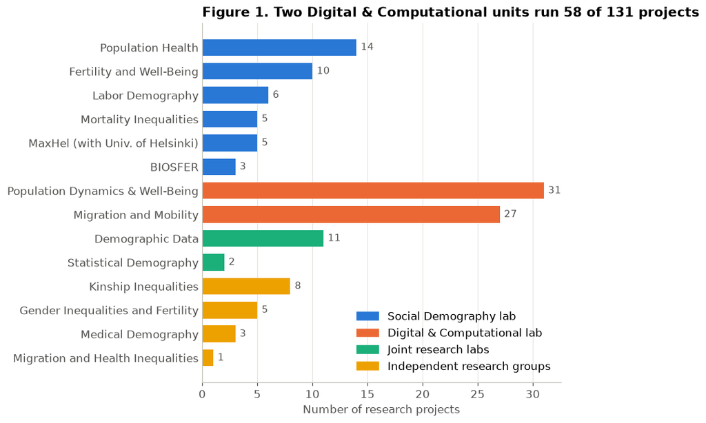

```python
per_unit = (projects.groupby(["lab", "unit"]).size().rename("n").reset_index())
per_unit["lab"] = pd.Categorical(per_unit["lab"], LAB_ORDER, ordered = True)
per_unit = per_unit.sort_values(["lab", "n"], ascending = [False, True])
per_unit["label"] = per_unit["unit"].map(short_unit)

fig, ax = plt.subplots(figsize = (8, 6))
ax.barh(per_unit["label"], per_unit["n"],
        color = per_unit["lab"].map(LAB_COLORS), height = 0.7)
for y, n in enumerate(per_unit["n"]):
    ax.text(n + 0.4, y, str(n), va = "center", fontsize = 10, color = INK_2)
ax.set_title("Figure 1. Two Digital & Computational units run 58 of 131 projects")
ax.set_xlabel("Number of research projects")
ax.grid(axis = "y", visible = False)
ax.tick_params(axis = "y", length = 0)
handles = [plt.Rectangle((0, 0), 1, 1, color = LAB_COLORS[l]) for l in LAB_ORDER]
ax.legend(handles, LAB_ORDER, loc = "lower right")
plt.tight_layout()
plt.show()
```

**What it shows.** Research is unevenly spread across the 14 units. The Digital & Computational lab has only two units, but they run 58 of the 131 projects (44%). Those two units also account for 141 of the 226 external collaborator places on projects (62%, Table 3), so this lab works with outside partners far more than the others. The Social Demography lab spreads its 43 projects across six smaller units, yet it lists the most publications (856, half of the institute's total). Its work is more often published as many papers per project than run as many separate projects.

The Joint research labs show the opposite of the Digital lab: few projects (13) but many publications (512). Demographic Data maintains large shared databases, so a handful of long-running projects lead to many papers.

**Research topics.**

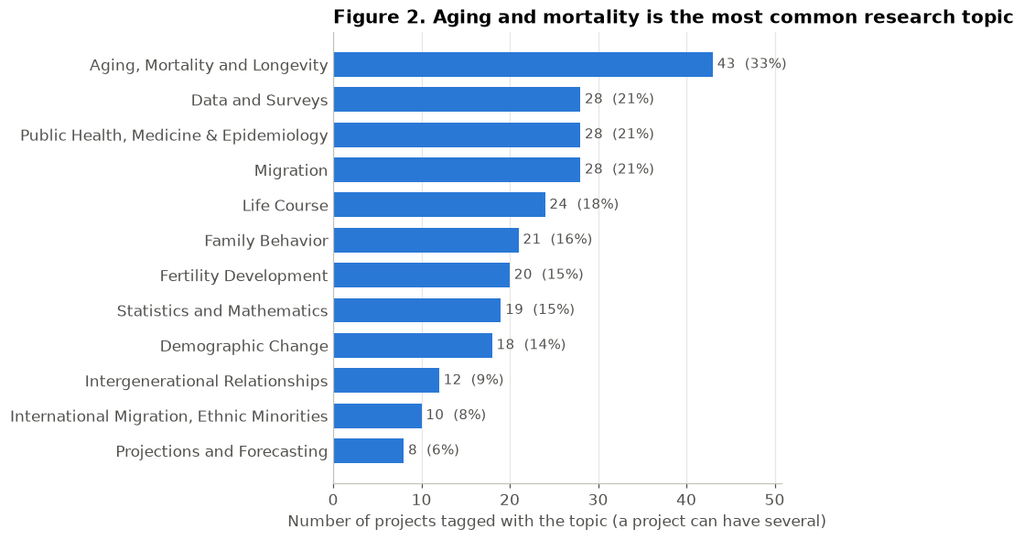

```python
topic_counts = (project_keywords.drop_duplicates(["project_url", "keyword"])
                                ["keyword"].value_counts().head(12).sort_values()
                                .rename(index = {"Health Care, Public Health, Medicine, and Epidemiology":
                                                 "Public Health, Medicine & Epidemiology"}))
share = topic_counts / len(projects)

fig, ax = plt.subplots(figsize = (8, 5.5))
ax.barh(topic_counts.index, topic_counts.values, color = BLUE, height = 0.7)
for y, (n, s) in enumerate(zip(topic_counts.values, share.values)):
    ax.text(n + 0.5, y, f"{n}  ({s:.0%})", va = "center", fontsize = 10, color = INK_2)
ax.set_title("Figure 2. Aging and mortality is the most common research topic")
ax.set_xlabel("Number of projects tagged with the topic (a project can have several)")
ax.set_xlim(0, topic_counts.max() * 1.18)
ax.grid(axis = "y", visible = False)
ax.tick_params(axis = "y", length = 0)
plt.tight_layout()
plt.show()
```

**What it shows.** Aging, mortality and longevity is MPIDR's core topic: a third of all projects (43) carry this tag, well ahead of any other. Three topics share second place at 28 projects each: migration, public health and data and surveys. The data-and-surveys tag and statistics (19 projects) show that much of the work is about building data and methods, not only studying populations. Family topics (life course, family behavior and fertility) together make up the next group. Because a project can carry several tags, the percentages add up to more than 100%.

**Regions studied.**

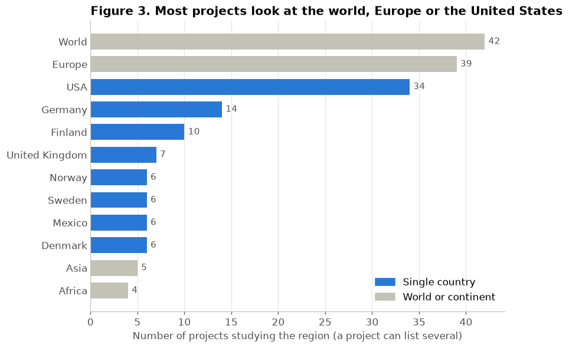

```python
WIDE_AREAS = ["World", "Europe", "Asia", "Africa", "Latin America",
              "America", "OECD countries"]
region_counts = (project_regions.drop_duplicates(["project_url", "region"])
                                ["region"].value_counts().head(12).sort_values())
colors = [GRAY if r in WIDE_AREAS else BLUE for r in region_counts.index]

fig, ax = plt.subplots(figsize = (8, 5.5))
ax.barh(region_counts.index, region_counts.values, color = colors, height = 0.7)
for y, n in enumerate(region_counts.values):
    ax.text(n + 0.4, y, str(n), va = "center", fontsize = 10, color = INK_2)
ax.set_title("Figure 3. Most projects look at the world, Europe or the United States")
ax.set_xlabel("Number of projects studying the region (a project can list several)")
ax.grid(axis = "y", visible = False)
ax.tick_params(axis = "y", length = 0)
ax.legend([plt.Rectangle((0, 0), 1, 1, color = BLUE), plt.Rectangle((0, 0), 1, 1, color = GRAY)],
          ["Single country", "World or continent"], loc = "lower right")
plt.tight_layout()
plt.show()
```

**What it shows.** Many projects take a wide view: 42 study the world as a whole and 39 study Europe. Among single countries, the United States (34 projects) is studied far more than Germany (14), even though MPIDR is based in Germany. This likely reflects the large, open US data sources used by the digital and computational units. The four Nordic countries (Finland, Norway, Sweden and Denmark) together appear 28 times. They are known for complete population registers, and Finland also has the joint MaxHel center with the University of Helsinki. Asia (5) and Africa (4) are rarely the focus, so the institute's research is centered on rich, data-rich countries.

### B. Who does the research?

**Projects per researcher.**

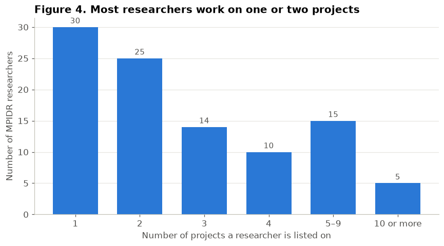

```python
projects_per_person = members.groupby("member_url").size()
bins   = [0, 1, 2, 3, 4, 9, 100]
labels = ["1", "2", "3", "4", "5–9", "10 or more"]
person_bands = (pd.cut(projects_per_person, bins, labels = labels)
                  .value_counts().reindex(labels))

fig, ax = plt.subplots()
ax.bar(person_bands.index, person_bands.values, color = BLUE, width = 0.7)
for x, n in enumerate(person_bands.values):
    ax.text(x, n + 0.6, str(n), ha = "center", fontsize = 10, color = INK_2)
ax.set_title("Figure 4. Most researchers work on one or two projects")
ax.set_xlabel("Number of projects a researcher is listed on")
ax.set_ylabel("Number of MPIDR researchers")
ax.grid(axis = "x", visible = False)
plt.tight_layout()
plt.show()
```

**What it shows.** Of the 99 MPIDR researchers named on project pages, 30 work on just one project and 25 on two, so more than half are on one or two projects (median: two). A few people are listed on far more projects: the two lab directors appear on 45 and 28 projects, and three senior researchers on 10 to 14 each. Project work is therefore spread widely, with a small group of senior staff who lead or oversee a large share of it. Researchers who have left MPIDR are no longer listed, so these counts describe today's staff only.

**Working with outside researchers.**

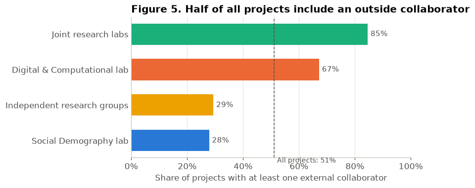

```python
ext_share = (projects.assign(has_external = projects["n_external"] > 0)
                    .groupby("lab")["has_external"].mean()
                    .reindex(LAB_ORDER).sort_values())
overall = (projects["n_external"] > 0).mean()

fig, ax = plt.subplots(figsize = (8, 3.6))
ax.barh(ext_share.index, ext_share.values,
        color = [LAB_COLORS[l] for l in ext_share.index], height = 0.6)
for y, s in enumerate(ext_share.values):
    ax.text(s + 0.01, y, f"{s:.0%}", va = "center", fontsize = 10, color = INK_2)
ax.axvline(overall, color = INK_2, linewidth = 1, linestyle = "--")
ax.text(overall + 0.01, -0.62, f"All projects: {overall:.0%}",
        fontsize = 9, color = INK_2)
ax.set_title("Figure 5. Half of all projects include an outside collaborator")
ax.set_xlabel("Share of projects with at least one external collaborator")
ax.xaxis.set_major_formatter(mtick.PercentFormatter(1.0))
ax.set_xlim(0, 1)
ax.grid(axis = "y", visible = False)
ax.tick_params(axis = "y", length = 0)
plt.tight_layout()
plt.show()
```

**What it shows.** 51% of projects list at least one researcher from outside MPIDR. This differs a lot by lab. The Joint research labs (85%) are partnerships with other institutions by design, and the Digital & Computational lab (67%) also works with outside partners on most projects. In the Social Demography lab and the Independent research groups, fewer than a third of projects include outside researchers, so their projects are mostly run in-house.

### C. What does MPIDR publish, and how has it changed?

**Publication types.**

```python
by_type = (pubs.groupby("pub_type")
               .agg(n = ("pub_url", "size"),
                    oa = ("open_access", "mean"),
                    authors = ("n_authors", "median"))
               .sort_values("n", ascending = False)
               .reset_index())
by_type["share"] = by_type["n"] / by_type["n"].sum()
t2_table = (by_type[["pub_type", "n", "share", "oa", "authors"]]
              .rename(columns = {"pub_type": "Publication type", "n": "Publications",
                                 "share": "Share of all", "oa": "Open access",
                                 "authors": "Median authors"}))
show_table(t2_table,
           "Table 4. Publications listed by MPIDR units, by type (all years)",
           {"Share of all": lambda v: "<1%" if v < 0.01 else f"{v:.0%}", "Open access": "{:.0%}", "Median authors": "{:.1f}"})
```

Table 4. Publications listed by MPIDR units, by type (all years)

| Publication type | Publications | Share of all | Open access | Median authors |
| --- | --- | --- | --- | --- |
| Journal article | 1,093 | 64% | 71% | 4.0 |
| MPIDR working paper | 298 | 17% | 100% | 3.0 |
| Book chapter | 135 | 8% | 34% | 3.0 |
| Preprint | 56 | 3% | 100% | 4.0 |
| Other paper | 53 | 3% | 36% | 3.0 |
| MPIDR technical report | 20 | 1% | 5% | 2.5 |
| External link | 19 | 1% | 0% | 9.0 |
| Dissertation | 17 | <1% | 0% | 1.0 |
| Book | 10 | <1% | 20% | 2.0 |
| Software | 8 | <1% | 0% | 2.0 |
| Report | 1 | <1% | 100% | 4.0 |

*Each publication link is counted once here, so a working paper and its later journal version count as two. In the charts below each pair is counted once (1,606 distinct papers).*

**What it shows.** Journal articles make up nearly two thirds of the list (1,093), followed by MPIDR's own working paper series (298). Working papers and preprints are always free to read, while about 7 in 10 journal articles and only a third of book chapters are open access. A typical journal article has four authors. Dissertations have one author, and the external links include large international studies with many authors.

**Publications per year.**

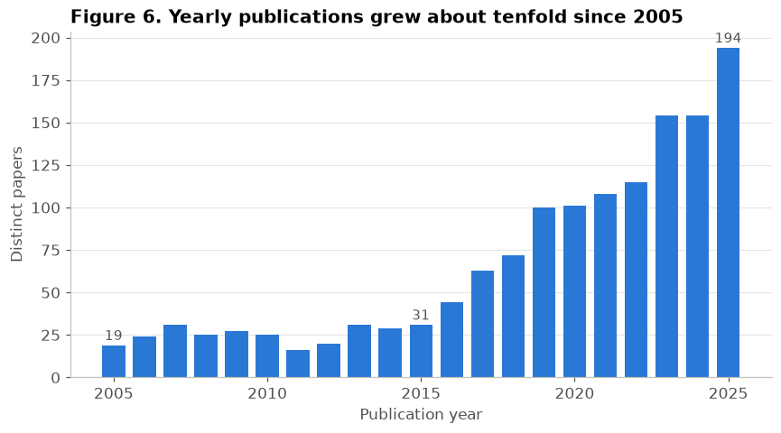

```python
in_range = papers[papers["pub_year"].between(FIRST_YEAR, LAST_YEAR)]
per_year = in_range.groupby("pub_year").size()

fig, ax = plt.subplots()
ax.bar(per_year.index, per_year.values, color = BLUE, width = 0.75)
for yr in [FIRST_YEAR, 2015, LAST_YEAR]:
    ax.text(yr, per_year[yr] + 3, str(per_year[yr]), ha = "center",
            fontsize = 10, color = INK_2)
ax.set_title("Figure 6. Yearly publications grew about tenfold since 2005")
ax.set_xlabel("Publication year")
ax.set_ylabel("Distinct papers")
ax.set_xticks(range(FIRST_YEAR, LAST_YEAR + 1, 5))
ax.grid(axis = "x", visible = False)
plt.tight_layout()
plt.show()
```

**What it shows.** From 2005 to 2015 the units listed a steady 16 to 31 papers per year. Output then rose quickly, passing 100 papers a year in 2019 and reaching 194 in 2025. The 2026 figure (153 so far) is left out because the year is not over.

**Caution.** These lists come from the units that exist today. Papers by earlier units and former staff are mostly missing, so the early years are undercounted and part of the growth reflects how the website is organized. The rise since 2016 is still large, and it matches the growth of the newer digital and computational units.

**Open access over time.**

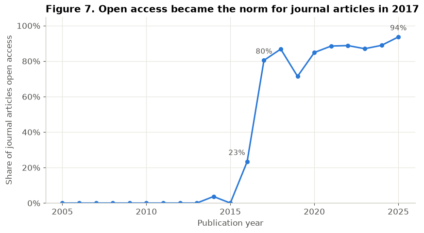

```python
journal = in_range[in_range["pub_type"] == "Journal article"]
oa_year = journal.groupby("pub_year")["open_access"].mean()

fig, ax = plt.subplots()
ax.plot(oa_year.index, oa_year.values, color = BLUE, linewidth = 2,
        marker = "o", markersize = 5)
for yr in [2016, 2017, LAST_YEAR]:
    ax.annotate(f"{oa_year[yr]:.0%}", (yr, oa_year[yr]), textcoords = "offset points",
                xytext = (-14 if yr == 2016 else 0, 9), ha = "center", fontsize = 10, color = INK_2)
ax.set_title("Figure 7. Open access became the norm for journal articles in 2017")
ax.set_xlabel("Publication year")
ax.set_ylabel("Share of journal articles open access")
ax.yaxis.set_major_formatter(mtick.PercentFormatter(1.0))
ax.set_ylim(0, 1.05)
ax.set_xticks(range(FIRST_YEAR, LAST_YEAR + 1, 5))
plt.tight_layout()
plt.show()
```

**What it shows.** Until 2016 almost none of MPIDR's journal articles were marked open access (0% in most years, 23% in 2016). In 2017 the share jumped to 80%, and it has stayed between 71% and 94% since, reaching 94% in 2025. A change this sudden points to a policy or funding decision, such as paying journals to make papers free, rather than a gradual change in researchers' habits. The data cannot show the cause. Part of the jump may also come from how the website marks older papers.

**Group size: how many authors write a paper?**

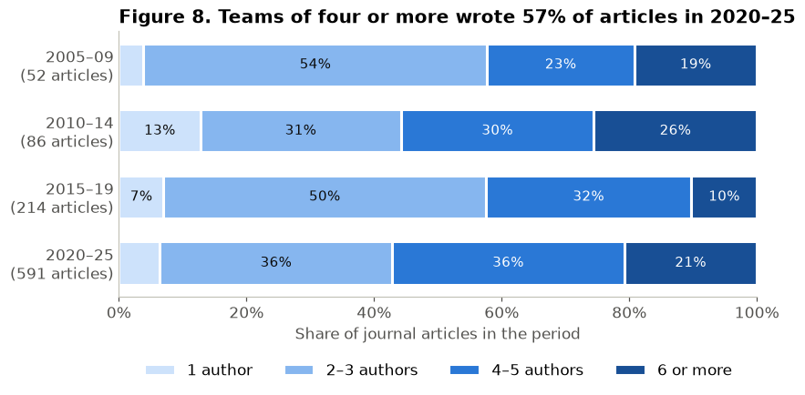

```
Median authors by period: {'2005–09': 3.0, '2010–14': 4.0, '2015–19': 3.0, '2020–25': 4.0}
Share with 4+ authors:   {'2005–09': 0.42, '2010–14': 0.56, '2015–19': 0.43, '2020–25': 0.57}
```

```python
BANDS      = ["1 author", "2–3 authors", "4–5 authors", "6 or more"]
BAND_COLOR = ["#cde2fb", "#86b6ef", "#2a78d6", "#184f95"]
PERIODS    = ["2005–09", "2010–14", "2015–19", "2020–25"]

team = journal.assign(
    period = pd.cut(journal["pub_year"], [2004, 2009, 2014, 2019, 2025], labels = PERIODS),
    band   = pd.cut(journal["n_authors"], [0, 1, 3, 5, 10_000], labels = BANDS))
band_share = pd.crosstab(team["period"], team["band"], normalize = "index")
period_n   = team["period"].value_counts().reindex(PERIODS)

fig, ax = plt.subplots(figsize = (8, 4.2))
left = pd.Series(0.0, index = PERIODS)
ylabels = [f"{p}\n({n} articles)" for p, n in period_n.items()]
for band, color in zip(BANDS, BAND_COLOR):
    vals = band_share[band].reindex(PERIODS)
    ax.barh(ylabels, vals, left = left, color = color, height = 0.65,
            edgecolor = "white", linewidth = 2, label = band)
    for y, (l, v) in enumerate(zip(left, vals)):
        if v >= 0.07:
            ax.text(l + v / 2, y, f"{v:.0%}", ha = "center", va = "center", fontsize = 10,
                    color = "white" if band in BANDS[2:] else INK)
    left += vals
ax.invert_yaxis()
ax.set_title("Figure 8. Teams of four or more wrote 57% of articles in 2020–25")
ax.set_xlabel("Share of journal articles in the period")
ax.xaxis.set_major_formatter(mtick.PercentFormatter(1.0))
ax.set_xlim(0, 1)
ax.grid(False)
ax.tick_params(axis = "y", length = 0)
ax.legend(ncol = 4, loc = "upper center", bbox_to_anchor = (0.5, -0.2))
plt.tight_layout()
plt.show()

summary = (team.groupby("period", observed = True)["n_authors"]
               .agg(median = "median", four_plus = lambda s: (s >= 4).mean()))
print("Median authors by period:", summary["median"].to_dict())
print("Share with 4+ authors:  ", summary["four_plus"].round(2).to_dict())
```

**What it shows.** Research at MPIDR is a team activity. Only about 1 in 15 journal articles has a single author. From 2005–09 to 2020–25 the typical team grew from three to four authors, and the share of articles with four or more authors rose from 42% to 57%. The change was not steady. Periods with larger teams (2010–14, 2020–25) alternate with periods dominated by 2–3 author papers (2005–09, 2015–19). The 2020s, when most of the papers were published, have the most papers by teams of four or more.

Large teams also include a few very large studies. Several papers since 2019 list around 100 authors, usually international health studies that MPIDR researchers contribute to. This is why the chart shows team-size groups rather than an average, which a handful of such papers would push up. The 2005–09 group is small (52 articles), so its shares are less certain.

## 6. Discussion

**Takeaways.** MPIDR is a research institute built around teams and partnerships. Most researchers work on one or two projects, half of all projects include an outside partner, and journal articles are increasingly written by four or more authors. The institute's research is broad, with aging and mortality at its center and a strong focus on data and methods. Its newer Digital & Computational lab runs the largest share of projects and works most with outside researchers. The institute's publishing has grown quickly since 2016, and nearly all of it is now free to read.

**Limitations.**

- **The website shows the present, not the past.** Only current units, projects and staff are listed. Papers by former units and researchers are mostly missing, so the growth in Figure 6 is partly an artifact, and project counts per researcher describe today's staff only.
- **Tags are incomplete.** About a quarter of projects (31) have no region tag and 8 have no topic tag, so Figures 2 and 3 undercount some topics and places.
- **Authors are counted from the website's lists.** The data show how many authors a paper has, but not which of them belong to MPIDR. Telling internal and external authors apart over time would need outside data on each author's affiliation.
- **The causes of the trends are not in the data.** The open-access jump in 2017 and the shifts in team size are described here, not explained.

**Next steps.** A fuller history could come from the institute's annual reports or a bibliographic database. Linking authors to their institutions would show whether the growth in team size comes from more collaboration with other institutes.